# W3cubDocs

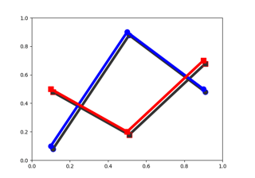

[SVG Filter Line](https://matplotlib.org/3.5.1/gallery/misc/svg_filter_line.html#sphx-glr-gallery-misc-svg-filter-line-py)

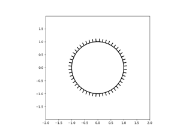

[TickedStroke patheffect](https://matplotlib.org/3.5.1/gallery/misc/tickedstroke_demo.html#sphx-glr-gallery-misc-tickedstroke-demo-py)

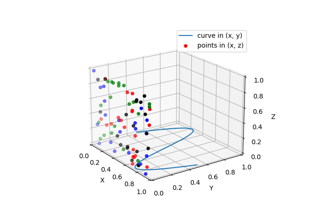

[Plot 2D data on 3D plot](https://matplotlib.org/3.5.1/gallery/mplot3d/2dcollections3d.html#sphx-glr-gallery-mplot3d-2dcollections3d-py)

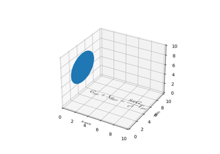

[Draw flat objects in 3D plot](https://matplotlib.org/3.5.1/gallery/mplot3d/pathpatch3d.html#sphx-glr-gallery-mplot3d-pathpatch3d-py)

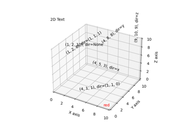

[Text annotations in 3D](https://matplotlib.org/3.5.1/gallery/mplot3d/text3d.html#sphx-glr-gallery-mplot3d-text3d-py)

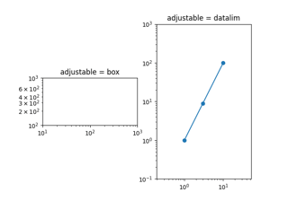

[Loglog Aspect](https://matplotlib.org/3.5.1/gallery/scales/aspect_loglog.html#sphx-glr-gallery-scales-aspect-loglog-py)

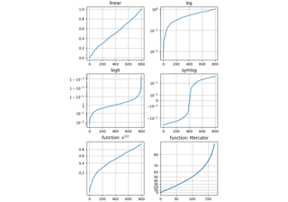

[Scales](https://matplotlib.org/3.5.1/gallery/scales/scales.html#sphx-glr-gallery-scales-scales-py)

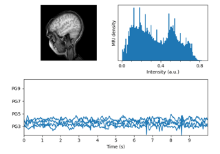

[MRI With EEG](https://matplotlib.org/3.5.1/gallery/specialty_plots/mri_with_eeg.html#sphx-glr-gallery-specialty-plots-mri-with-eeg-py)

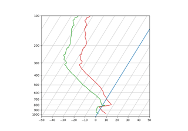

[SkewT-logP diagram: using transforms and custom projections](https://matplotlib.org/3.5.1/gallery/specialty_plots/skewt.html#sphx-glr-gallery-specialty-plots-skewt-py)

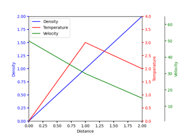

[Multiple Yaxis With Spines](https://matplotlib.org/3.5.1/gallery/spines/multiple_yaxis_with_spines.html#sphx-glr-gallery-spines-multiple-yaxis-with-spines-py)

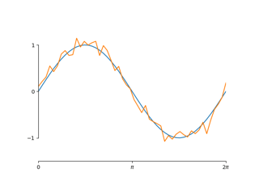

[Custom spine bounds](https://matplotlib.org/3.5.1/gallery/spines/spines_bounds.html#sphx-glr-gallery-spines-spines-bounds-py)

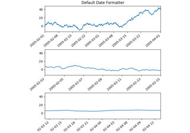

[Formatting date ticks using ConciseDateFormatter](https://matplotlib.org/3.5.1/gallery/ticks/date_concise_formatter.html#sphx-glr-gallery-ticks-date-concise-formatter-py)